« Retour au Portfolio

# Vizu_Exos_1

# Partie 1

## Introduction à matplotlib

### Les bases

**Cette itération a pour objectif de:**

1. Comprendre la manière dont est structurée un graphique
2. Acquérir le vocabulaire liée au tracé des courbes
3. Personnaliser vos figures afin de les rendre plus intelligibles
4. Réaliser différents types de graphiques:line,histogramme,scatter

```python
import matplotlib
import matplotlib.pyplot as plt
import numpy as np
```

**EXERCICE 01 Tracer une courbe**

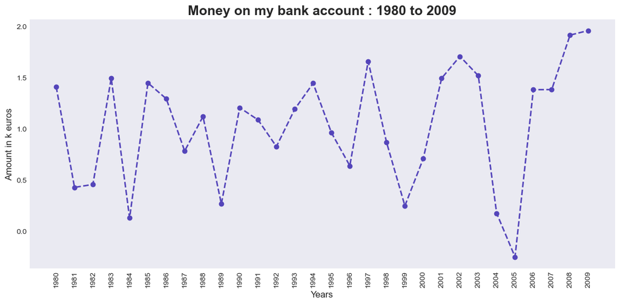

```python
# Exercice 01 - Help # ATTENTION EN NéGATIF

# voici la variable à plotter
y = np.random.randn(30).cumsum()

# Creation de la liste d'années (les abscisses):
x = np.arange(1980, 2010, 1)

# la taille de la figure est (14,6)
plt.figure(figsize=(14,6)) # Créer un cadre Taille de la figure

# Création de la figure et tracé de la courbe:
plt.plot(x, y,color= '#5445BA', marker='o', linestyle='--') #  arg = la couleur de la ligne a le code RGB : #5445BAt
#arg = marker =  pour afficher les marques #arg = linestyle = pour afficher le style de la ligne

# Mise en forme du graphique (labels, titre, ticks):
# Pour le titre la font size est 18, font weight est "bold"
plt.title("Money on my bank account : 1980 to 2009", fontsize=18, fontweight='bold') # Titre du graphe
plt.xlabel("Years") # Label de l'axe des x
plt.ylabel("Amount in k euros") # Label de l'axe des y

# Les labels des ticks sont en rotation de 90 degrées.
plt.xticks(x, rotation=90) # np.arange(min(x), max(x)+1, 2.0), rotation=90) #permet de modifier les ticks (valeurs) de l'axe des x afficher Attention à l'ordre des arguments
plt.yticks() #permet de modifier les ticks (valeurs) de l'axe des y

# Affichage de la courbe:
plt.show()
```

```python
plt.rcParams['figure.figsize'] = (10, 5) # Taille du graphe
plt.rcParams['lines.linewidth'] = 2 # Épaisseur de la ligne
plt.rcParams['lines.color'] = 'r' # Couleur de la ligne
plt.rcParams['lines.linestyle'] = '--' # Style de la ligne
```

**Exercice 02 Tracer un histogramme**

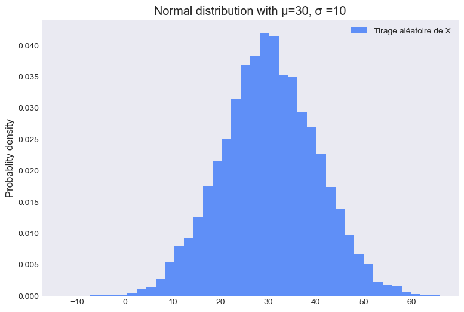

```python
# Créer une distribution de 10 000 valeurs suivant une loie normale centrée sur mu=30 avec un écart-type de sigma=10
mu, sigma = 30, 10
x = np.random.normal(mu, sigma, 10000)

# figsize=(9,6)
plt.figure(figsize=(9,6)) # Taille de la figure

# histogramme avec 40 bins
plt.hist(x, bins=40, density=True, alpha=0.6, color='#0352fc') # arg = density=True pour normaliser l'histogramme
# arg = alpha pour la transparence de la couleur # arg = color pour la couleur de l'histogramme
# #arg = bins pour le nombre de bins de barres dans l'histogramme

# Ne pas oublier le ylabel, la légende et le titre!
plt.ylabel("Probablity density")
plt.title("Normal distribution with µ=30, σ =10")
plt.legend(["Tirage aléatoire de X"])

# Affichage de la courbe:
plt.show()
```

**Exercice 03 Essayez d'autres styles**

1. Quels sont les styles disponibles ?

6 ty pes de Graphique : line plot scatter plot bar plot histogramme box plot area plot

30 styles différents

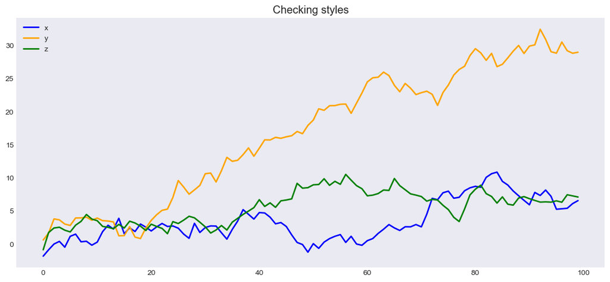

```python
# Changez le style !
#plt.style.use("avec le style choisit) liste des 30 styles sur cf https://matplotlib.org/stable/gallery/style_sheets/style_sheets_reference.html?utm_source=www.monshotdata.com&utm_medium=referral&utm_campaign=style-matplotlib-rendre-ses-traces-plus-attractifs")
# Style playing
plt.figure(figsize=(14,6))

plt.plot(np.random.randn(100).cumsum(), label="x", linestyle="-", color = 'blue')
plt.plot(np.random.randn(100).cumsum(), label="y", linestyle="-", color = 'orange')
plt.plot(np.random.randn(100).cumsum(), label="z", linestyle="-", color = 'green')
plt.title("Checking styles")

plt.legend()
plt.show()
```

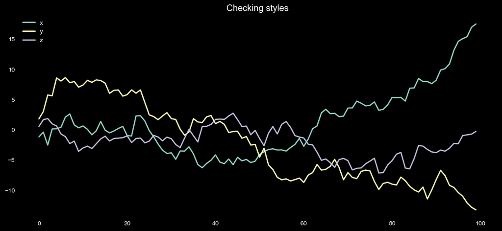

```python
# Changez le style !
plt.style.use("dark_background")
# Style playing
plt.figure(figsize=(14,6))

plt.plot(np.random.randn(100).cumsum(), label="x", linestyle="-")
plt.plot(np.random.randn(100).cumsum(), label="y", linestyle="-")
plt.plot(np.random.randn(100).cumsum(), label="z", linestyle="-")
plt.title("Checking styles")

plt.legend()
plt.show()
```

**Exercice 04 Changez les paramétres**

Matplotlib propose un ensemble de paramètres par défaut qui sont bien pratiques, mais souvent on se retrouve à répéter régulièrement une instruction.

Le cas typique est la taille par défaut d'une figure. Lorsque nous sommes sur notre notebook nous avons regulièrement besoin d'une figure de plus grand taille.

Les paramètres sont stockés dans un `dict()`, ce dictionnaire est l'attribut `rcParams` de `plt`.

1. Explorez rapidement ce dictionnaire.

```python
print(plt.rcParams) #Affiche les Paramétres de Matplotlib
```

[output not shown]

[output cut: 267 more lines]

[output not shown]

2. Changez le paramètre de la taille de figure par défaut afin d'obtenir un aspect qui vous convient.

```python
#plt.rcParams["avec la ligne du paramétre à changer"] c'est en mode permanet jusqu'au
plt.rcParams['figure.facecolor'] = '#f2F2F2'
plt.rcParams['figure.figsize'] = (14, 6)   #(largeur , hauteur)
plt.rcParams['lines.linewidth'] = 2
```

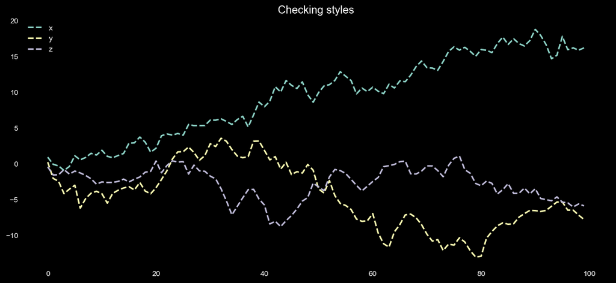

```python
# Changez le style !
plt.style.use("dark_background")
# Style playing
plt.figure(figsize=(14,6))

plt.plot(np.random.randn(100).cumsum(), label="x")
plt.plot(np.random.randn(100).cumsum(), label="y")
plt.plot(np.random.randn(100).cumsum(), label="z")
plt.title("Checking styles")

plt.legend()
plt.show()
```

3. Nous allons par la suite utiliser le style seaborn, mais le background attire trop l'oeil. Changez l'attribut `facecolor`. Comme par exemple la couleur RGB `#f2f2f2` ou alors `#f1f3f9`.

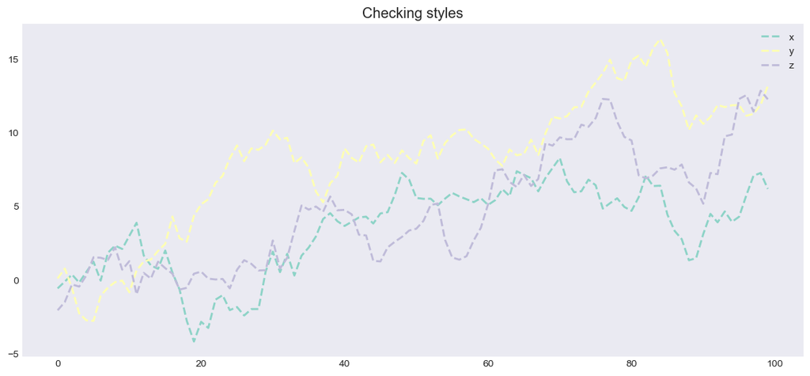

```python
plt.style.use('seaborn-v0_8-dark')   # le plt.style.use("choix du style permet d'appliquer le style choisit")

# Style playing
plt.figure(figsize=(14,6))

plt.plot(np.random.randn(100).cumsum(), label="x")
plt.plot(np.random.randn(100).cumsum(), label="y")
plt.plot(np.random.randn(100).cumsum(), label="z")
plt.title("Checking styles")

plt.legend()
plt.show()
```

# Exercice 5 Tracer des subplots

## Plotter avec l'interface Artist.

`pyplot` est une interface qui permet de travailler sur des cas de visualisation faciles. Mais dès que nous souhaitons aller plus loin, l'interface trouve ses limites.

Le cas le plus courant est lorsque nous souhaitons tracer plusieurs graphiques (a.k.a. `axes`) dans le même canevas (a.k.a. `figure`).

Pour tracer des subplots, nous devons travailler directement avec les objets de la classe `Figure` et `Axes`... c'est à dire sur les objets de la couche *Artist*.

Voici un exemple :

```
    fig = plt.figure() # créer un objet de type Figure (canevas)
    ax = fig.add_subplot(nrows, ncols, plot_number) # créer des objets de type 'Axes' supplémentaires
```

- `nrows` et `ncols` decoupe la figure en (`nrows` * `ncols`) sub-axes,
- `plot_number` est l'identifiant d'un plot particulier.

**Remarque** `plot_number` commence à 1, et fini à `nrows` * `ncols`

L'image suivante devrait vous aider à comprendre la logique des subplots :

[figure not shown]

# Question :

Reproduisez (avec exactitude) la figure suivante:

[figure not shown]

Quelques pistes :

- Il s'agit d'une grille 2x2
- Pour le texte sur le 4ème "axes" vous pouvez explorer la fonction `text` qui se trouve dans l'objet du type `Axes`.
- La couleur du texte est `green`

https://matplotlib.org/stable/gallery/pyplots/text_commands.html

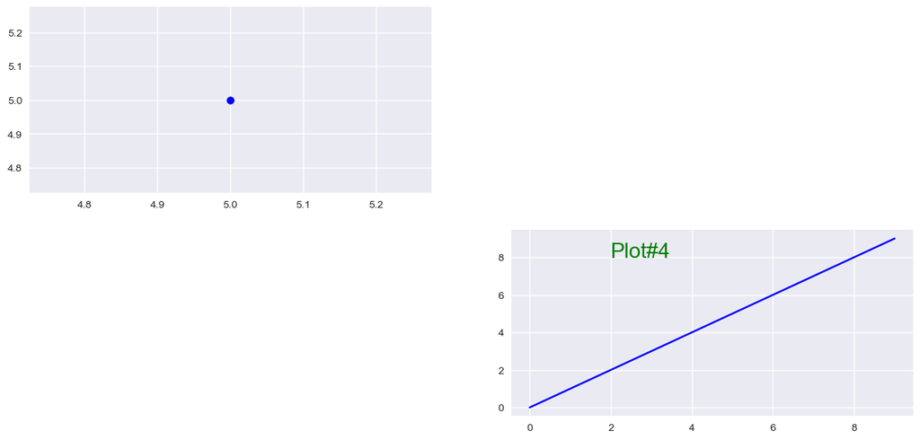

```python
# TODO Exercice 05: Tracer des subplots
plt.style.use('seaborn-v0_8')
fig = plt.figure(figsize=(15,7)) # créer un objet de type Figure (canevas)
ax1 = fig.add_subplot(2, 2, 1) # créer des objets de type 'Axes' supplémentaires
ax2 = fig.add_subplot(2, 2, 4) # créer des objets de type 'Axes' supplémentaires

ax1.scatter(5,5, color='blue')
# ax1.grid(which='major', axis='x', color='g', linewidth=2)
# ax1.grid(which='major', axis='y', color='g',)
ax2.plot((0,9),(0,9), color='blue', linestyle="-")   #(range(10))peut remplace (0.9) (0.9)
ax2.text(2,8,'Plot#4', color = 'green', fontsize = 20 )
```

# Exercice 06 de la couche 'Pyplot' à 'Artist'

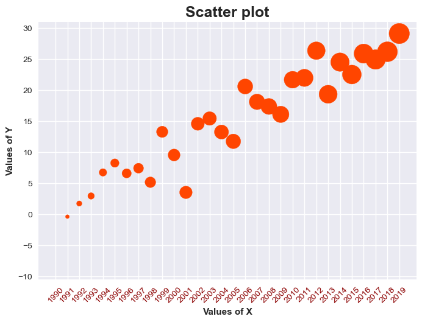

```python
x = np.arange(30)
y = np.arange(30) + 3*np.random.randn(30)

plt.scatter(x , y , color="orangered", s=20*x)

plt.title("Scatter plot", fontsize=18, fontweight="bold")
plt.xlabel("Values of X", fontweight="bold")
plt.ylabel("Values of Y", fontweight="bold")
plt.xticks(x, labels=x + 1990, rotation=45, color="darkred")
plt.show()
```

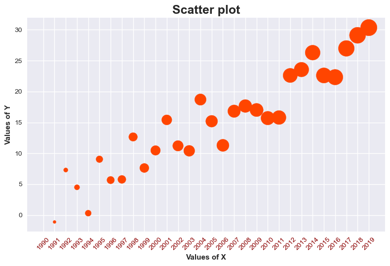

```python
# TODO Exercice 06: de la couche 'Pyplot' à 'Artist'

# Données (identiques)
x = np.arange(30)
y = np.arange(30) + 3*np.random.randn(30)

# 1. Créer la Figure (le conteneur) et les Axes (la zone de traçage)
fig, ax = plt.subplots()

# 2. Utiliser les méthodes de l'objet Axes (ax)

# plt.scatter(...) devient ax.scatter(...)
ax.scatter(x, y, color="orangered", s=20*x)

# plt.title(...) devient ax.set_title(...)
ax.set_title("Scatter plot", fontsize=18, fontweight="bold")

# plt.xlabel(...) devient ax.set_xlabel(...)
ax.set_xlabel("Values of X", fontweight="bold")

# plt.ylabel(...) devient ax.set_ylabel(...)
ax.set_ylabel("Values of Y", fontweight="bold")

# plt.xticks(positions, labels=..., ...) devient ax.set_xticks(positions) et ax.set_xticklabels(labels, ...)
ax.set_xticks(x)
ax.set_xticklabels(x + 1990, rotation=45, color="darkred")

# Ajustement pour que les étiquettes ne se chevauchent pas (souvent nécessaire)
fig.tight_layout()

# Afficher la figure
plt.show()
```